# Sentiment Analysis of Primeminister Speeches

2026-05-26

Introduction: In this analysis we are examining the emotional value of danish prime ministers speeches. There is a speech from each term of office from the year 1999 to 2025. Only the relevant paragraph about immigrants is taken from each speech.

##Step 1 First install the needed packages. Danish AFINN dictionary is loaded directly from its source repository using a UTF-8 encoding configuration to preserve Danish special characters (æ,ø,å).

```r
library(pdftools)
library(tidytext)
library(tidyverse)
library(ggwordcloud)

dir.create("data")

#the Danish AFINN dataset
url <- "https://raw.githubusercontent.com/fnielsen/afinn/master/afinn/data/AFINN-da-32.txt"

danish_lexicon <- read.delim(url, header = FALSE,
  col.names = c("word", "value"),
  stringsAsFactors = FALSE,
  encoding = "UTF-8")%>%
  mutate(word = tolower(word))
```

Helle Thorning Schmidt speech from 2012

```r
file_to_read <- "data/Thorning_2012.pdf"
raw_text <- pdftools::pdf_text(file_to_read)
speech_dataframe <- data.frame(text = raw_text, stringsAsFactors = FALSE)
cleaned_words <- speech_dataframe %>%
  unnest_tokens(word, text) %>%
  mutate(word = str_remove_all(word, "[[:punct:]]")) %>%
  filter(str_detect(word, "^[a-zæøå]+$"))
```

##Step 3 Here we isolate the emotional words that are present in both the text and the dictionary. With the print() we can see which words it found.

```r
matched_words <- cleaned_words %>%
  inner_join(danish_lexicon, by = "word")

print(matched_words %>% select(word, value) %>% distinct())
```

```
##            word value
## 1        truede    -2
## 2    kriminelle    -3
## 3        angreb    -1
## 4        begået     1
## 5         helst     1
## 6       stoppet    -1
## 7          true    -2
## 8          grov    -1
## 9  kriminalitet    -3
## 10     skyldige    -3
## 11      straffe    -2
## 12      udsatte    -2
## 13         svær    -2
## 14      frygter    -2
## 15        hjælp     2
## 16       hjælpe     2
## 17      flygter    -1
## 18       robust     2
## 19    retfærdig     2
## 20   muligheder     2
## 21         godt     3
## 22     ødelægge    -3
```

##Step 4 Finally we can calculate the emotional metrics for the speech.

```r
Thorning_summary <- matched_words %>%
  summarize(File_Analyzed = basename(file_to_read),
    Average_Sentiment  = mean(value),
    Total_Scored_Words = n())
print(Thorning_summary)
```

```
##       File_Analyzed Average_Sentiment Total_Scored_Words
## 1 Thorning_2012.pdf        -0.8461538                 26
```

##Step 5 Anders Fogh Rasmussen speech from 2005 Finding the pdf file and cleaning the data

```r
file_to_read <- "data/Fogh_2005.pdf"
raw_text <- pdftools::pdf_text(file_to_read)
speech_dataframe <- data.frame(text = raw_text, stringsAsFactors = FALSE)

cleaned_words <- speech_dataframe %>%
  unnest_tokens(word, text) %>%
  mutate(word = str_remove_all(word, "[[:punct:]]")) %>%
  filter(str_detect(word, "^[a-zæøå]+$"))
```

##Step 6 Isolating the emotional words

```r
matched_words <- cleaned_words %>%
  inner_join(danish_lexicon, by = "word")

print(matched_words %>% select(word, value) %>% distinct())
```

```
##            word value
## 1    skræmmende    -2
## 2     acceptere     1
## 3           slå    -1
## 4        mangel    -2
## 5      voldsomt    -2
## 6     risikerer    -2
## 7         slået    -2
## 8    kriminelle    -3
## 9  retsforfølge    -1
## 10       ønsker     2
## 11      støtter     2
## 12       håbløs    -2
## 13    vellykket     3
## 14       fremme     1
```

[output cut: 18 more lines]

##Step 7 Calculating the sentiment of the words

```r
Fogh_summary <- matched_words %>%
  summarize(File_Analyzed = basename(file_to_read),
    Average_Sentiment  = mean(value),
    Total_Scored_Words = n())
print(Fogh_summary)
```

```
##   File_Analyzed Average_Sentiment Total_Scored_Words
## 1 Fogh_2005.pdf        0.07692308                 39
```

##Step 8 Lars Løkke Rasmussen speech from 2010 Finding the pdf file and cleaning the data

```r
file_to_read <- "data/Løkke_2010.pdf"
raw_text <- pdftools::pdf_text(file_to_read)
speech_dataframe <- data.frame(text = raw_text, stringsAsFactors = FALSE)
cleaned_words <- speech_dataframe %>%
  unnest_tokens(word, text) %>%
  mutate(word = str_remove_all(word, "[[:punct:]]")) %>%
  filter(str_detect(word, "^[a-zæøå]+$"))
```

##Step 9 Isolating the emotional words

```r
matched_words <- cleaned_words %>%
  inner_join(danish_lexicon, by = "word")

print(matched_words %>% select(word, value) %>% distinct())
```

```
##               word value
## 1         mulighed     2
## 2             godt     3
## 3           chance     2
## 4        ambitiøse     2
## 5            trygt     2
## 6         velstand     3
## 7        betydning     2
## 8        afgørende     1
## 9           frihed     2
## 10         respekt     2
## 11      muligheder     2
## 12          tillid     2
## 13             når     1
## 14           udsat    -1
```

[output cut: 19 more lines]

##Step 10 Calculating the sentiment of the words

```r
Løkke10_summary <- matched_words %>%
  summarize(File_Analyzed = basename(file_to_read),
    Average_Sentiment  = mean(value),
    Total_Scored_Words = n())
print(Løkke10_summary)
```

```
##    File_Analyzed Average_Sentiment Total_Scored_Words
## 1 Løkke_2010.pdf         0.6744186                 43
```

##Step 11 Lars Løkke Rasmussens speech from 2017 Finding the pdf file and cleaning the data

```r
file_to_read <- "data/Løkke_2017.pdf"
raw_text <- pdftools::pdf_text(file_to_read)
speech_dataframe <- data.frame(text = raw_text, stringsAsFactors = FALSE)
cleaned_words <- speech_dataframe %>%
  unnest_tokens(word, text) %>%
  mutate(word = str_remove_all(word, "[[:punct:]]")) %>%
  filter(str_detect(word, "^[a-zæøå]+$"))
```

##Step 12 Isolating the emotional words

```r
matched_words <- cleaned_words %>%
  inner_join(danish_lexicon, by = "word")

print(matched_words %>% select(word, value) %>% distinct())
```

```
##           word value
## 1       kæmper    -2
## 2        stolt     2
## 3          ære     2
## 4          når     1
## 5       styrke     2
## 6       ønsker     2
## 7       hjælpe     2
## 8          håb     2
## 9        bedre     2
## 10      afvist    -2
## 11  gennemført     2
## 12   problemer    -2
## 13        løst     1
## 14       slået    -2
```

[output cut: 19 more lines]

##Step 13 Calculating the sentiment of the words

```r
Løkke17_summary <- matched_words %>%
  summarize(File_Analyzed = basename(file_to_read),
    Average_Sentiment  = mean(value),
    Total_Scored_Words = n())
print(Løkke17_summary)
```

```
##    File_Analyzed Average_Sentiment Total_Scored_Words
## 1 Løkke_2017.pdf         0.5555556                 45
```

##Step 14 Mette Frederiksen speech from 2022 Finding the pdf file and cleaning the data

```r
file_to_read <- "data/Frederiksen_2022.pdf"
raw_text <- pdftools::pdf_text(file_to_read)
speech_dataframe <- data.frame(text = raw_text, stringsAsFactors = FALSE)
cleaned_words <- speech_dataframe %>%
  unnest_tokens(word, text) %>%
  mutate(word = str_remove_all(word, "[[:punct:]]")) %>%
  filter(str_detect(word, "^[a-zæøå]+$"))
```

##Step 15 Isolating the emotional words

```r
matched_words <- cleaned_words %>%
  inner_join(danish_lexicon, by = "word")

print(matched_words %>% select(word, value) %>% distinct())
```

```
##            word value
## 1        ønsker     2
## 2  kriminalitet    -3
## 3        undgår    -1
## 4         mørke    -1
## 5     urimeligt    -2
## 6       forkert    -2
## 7      desværre    -2
## 8    meningsløs    -2
## 9          vold    -3
## 10      truende    -2
## 11       dårlig    -3
## 12   accepteret     1
## 13      flygter    -1
## 14         sjov     3
```

[output cut: 17 more lines]

##Step 16 Calculating the sentiment of the words

```r
Frederiksen_summary <- matched_words %>%
  summarize(File_Analyzed = basename(file_to_read),
    Average_Sentiment  = mean(value),
    Total_Scored_Words = n())
print(Frederiksen_summary)
```

```
##          File_Analyzed Average_Sentiment Total_Scored_Words
## 1 Frederiksen_2022.pdf         -1.282051                 39
```

##Step 17 Poul Nyrup Rasmussen speech from 1999 Finding the pdf file and cleaning the data

```r
file_to_read <- "data/Nyrup_1999.pdf"
raw_text <- pdftools::pdf_text(file_to_read)
speech_dataframe <- data.frame(text = raw_text, stringsAsFactors = FALSE)
cleaned_words <- speech_dataframe %>%
  unnest_tokens(word, text) %>%
  mutate(word = str_remove_all(word, "[[:punct:]]")) %>%
  filter(str_detect(word, "^[a-zæøå]+$"))
```

##Step 18 Isolating the emotional words

```r
matched_words <- cleaned_words %>%
  inner_join(danish_lexicon, by = "word")

print(matched_words %>% select(word, value) %>% distinct())
```

```
##             word value
## 1       usikkert    -2
## 2           værd     2
## 3         brokke    -2
## 4          sikre     1
## 5     usikkerhed    -2
## 6           tryg     2
## 7          frygt    -2
## 8          angst    -3
## 9     ulykkelige    -2
## 10          godt     3
## 11         bedre     2
## 12         svært    -2
## 13 frustrationer    -2
## 14        slemme    -2
## 15    værdifuldt     2
## 16           når     1
## 17  menneskeligt     2
## 18       trøster     2
## 19         skade    -2
## 20         stolt     2
## 21     ambitiøse     2
```

##Step 19 Calculating the sentiment of the words

```r
Nyrup_summary <- matched_words %>%
  summarize(File_Analyzed = basename(file_to_read),
    Average_Sentiment  = mean(value),
    Total_Scored_Words = n())
print(Nyrup_summary)
```

```
##    File_Analyzed Average_Sentiment Total_Scored_Words
## 1 Nyrup_1999.pdf         0.6363636                 33
```

##Step 20 Here we make a graph showing each speech in comparison

```r
timeline <- bind_rows(
  Thorning_summary,
  Fogh_summary,
  Løkke10_summary,
  Løkke17_summary,
  Frederiksen_summary,
  Nyrup_summary) %>%
  mutate(Year = c(2012, 2005, 2010, 2017, 2022, 1999),
         Prime_Minister = c("Thorning", "Fogh", "Løkke I", "Løkke II", "Frederiksen", "Nyrup")) %>%
  select(Year, Prime_Minister, Average_Sentiment, Total_Scored_Words, File_Analyzed)

knitr::kable(timeline, caption = "Historical Overview of Speech Sentiment")
```

Historical Overview of Speech Sentiment

| Year | Prime_Minister | Average_Sentiment | Total_Scored_Words | File_Analyzed |
| --- | --- | --- | --- | --- |
| 2012 | Thorning | -0.8461538 | 26 | Thorning_2012.pdf |
| 2005 | Fogh | 0.0769231 | 39 | Fogh_2005.pdf |
| 2010 | Løkke I | 0.6744186 | 43 | Løkke_2010.pdf |
| 2017 | Løkke II | 0.5555556 | 45 | Løkke_2017.pdf |
| 2022 | Frederiksen | -1.2820513 | 39 | Frederiksen_2022.pdf |
| 1999 | Nyrup | 0.6363636 | 33 | Nyrup_1999.pdf |

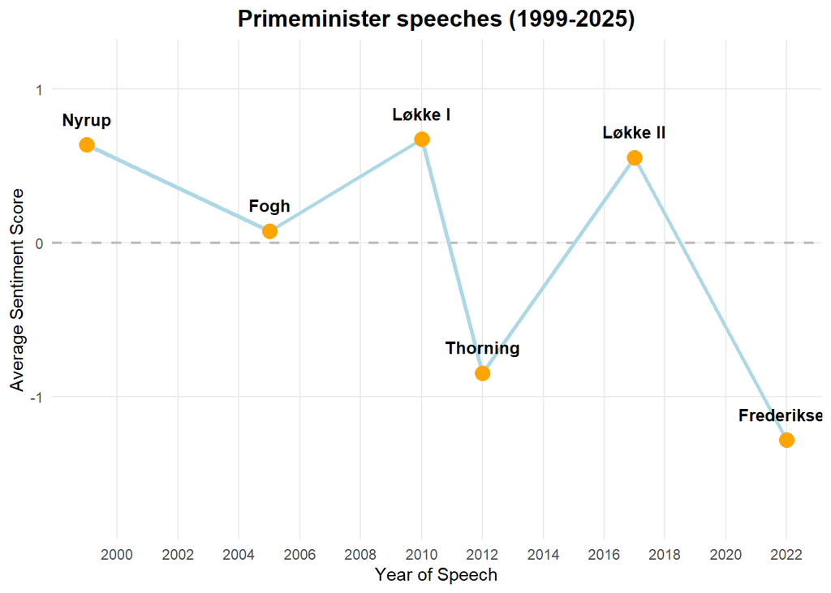

```r
ggplot(timeline, aes(x = Year, y = Average_Sentiment)) +
  geom_hline(yintercept = 0, color = "grey", linetype = "dashed", linewidth = 0.8) +
  geom_line(color = "lightblue", linewidth = 1.2) +
  geom_point(color = "orange", size = 4) +
  geom_text(aes(label = Prime_Minister), vjust = -1.5, size = 3.5, fontface = "bold") +
  scale_x_continuous(breaks = seq(2000, 2026, by = 2)) +
  expand_limits(y = c(min(timeline$Average_Sentiment) - 0.5,
                       max(timeline$Average_Sentiment) + 0.5)) +
  labs(title = "Primeminister speeches (1999-2025)",
    x = "Year of Speech",
    y = "Average Sentiment Score") +
  theme_minimal() +
    theme(plot.title = element_text(face = "bold", size = 14, hjust = 0.5),
    plot.subtitle = element_text(color = "dimgrey", size = 10, hjust = 0.5),
    panel.grid.minor = element_blank())
```